# Principle Components Analysis

Robert Saldivar

March 1, 2020

```r
#Loading the packages and the data that will be needed for this assignment.

library(tidyverse)
library(tidyr)
library(RColorBrewer)
library(here)
library(kableExtra)
library(knitr)
library(janitor)
library(naniar)
library(VIM)
library(skimr)
library(ggfortify)
#These are all of th packages that I think that I will use for this project

env_vars <- read_csv(here("data", "world_env_vars.csv")) #This is the raw data that I think I will use for this project.
```

*Task 2* Principle Componets Analysis

1. Description of the data and project. The data for this analysis was compiled and provided by @zander_venter which was gather from google earth engine. The data is of environmental variables of countries around the world. The analysis done in this Markdown document is a principle components analysis of the environmental variables and how they are displayed in a biplot.
2. Code used to wrangle the data and a biplot

```r
#Wrangling the data

env_vars_tidy <- env_vars %>%
  select(-Country) #This is removing the country column so that only the variables that can be included in a pca are in the data frame
```

```r
#Exploring the missingness of the environmental variables dataset

summary(env_vars_tidy)
```

```
##  accessibility_to_cities   elevation          aspect          slope
##  Min.   :    0.969       Min.   :   0.0   Min.   :  0.0   Min.   :0.00000
##  1st Qu.:   73.534       1st Qu.: 110.6   1st Qu.:159.1   1st Qu.:0.04247
##  Median :  214.508       Median : 301.4   Median :174.6   Median :0.39781
##  Mean   :  911.394       Mean   : 475.7   Mean   :169.1   Mean   :0.69560
##  3rd Qu.:  625.937       3rd Qu.: 598.9   3rd Qu.:186.7   3rd Qu.:1.08622
##  Max.   :15531.333       Max.   :5428.8   Max.   :310.9   Max.   :3.69839
##  NA's   :5               NA's   :6        NA's   :6       NA's   :6
##  cropland_cover    tree_canopy_cover isothermality   rain_coldestQuart
##  Min.   : 0.0000   Min.   : 0.000    Min.   :15.40   Min.   :   0.0312
##  1st Qu.: 0.3798   1st Qu.: 6.392    1st Qu.:33.82   1st Qu.:  80.9375
##  Median : 7.2246   Median :18.269    Median :53.77   Median : 179.9202
##  Mean   :17.1011   Mean   :22.055    Mean   :52.94   Mean   : 238.6579
##  3rd Qu.:27.6608   3rd Qu.:35.973    3rd Qu.:68.50   3rd Qu.: 312.4570
##  Max.   :77.5280   Max.   :71.896    Max.   :93.98   Max.   :1271.9904
##                    NA's   :11        NA's   :6       NA's   :6
##  rain_driestMonth  rain_driestQuart rain_mean_annual  rain_seasonailty
##  Min.   :  0.000   Min.   :  0.00   Min.   :  14.16   Min.   : 10.68
##  1st Qu.:  5.149   1st Qu.: 30.04   1st Qu.: 587.12   1st Qu.: 30.95
##  Median : 29.308   Median :104.80   Median :1043.14   Median : 50.71
##  Mean   : 40.628   Mean   :141.23   Mean   :1231.09   Mean   : 56.52
##  3rd Qu.: 58.934   3rd Qu.:204.14   3rd Qu.:1785.77   3rd Qu.: 80.28
##  Max.   :238.593   Max.   :843.66   Max.   :4547.62   Max.   :152.52
##  NA's   :5         NA's   :5        NA's   :5         NA's   :5
##  rain_warmestQuart rain_wettestMonth rain_wettestQuart  temp_annual_range
##  Min.   :   0.0    Min.   :  3.757   Min.   :   8.929   Min.   : 5.467
##  1st Qu.: 146.9    1st Qu.: 83.786   1st Qu.: 228.930   1st Qu.:11.773
##  Median : 254.5    Median :148.664   Median : 417.478   Median :19.841
##  Mean   : 334.3    Mean   :189.669   Mean   : 505.238   Mean   :20.932
##  3rd Qu.: 482.0    3rd Qu.:288.801   3rd Qu.: 762.228   3rd Qu.:27.938
##  Max.   :1385.1    Max.   :592.526   Max.   :1552.554   Max.   :50.631
##  NA's   :6         NA's   :5         NA's   :5          NA's   :6
##  temp_coldestQuart temp_diurnal_range temp_driestQuart temp_max_warmestMonth
##  Min.   :-28.507   Min.   : 2.879     Min.   :-19.85   Min.   : 0.9144
##  1st Qu.:  2.916   1st Qu.: 7.181     1st Qu.: 11.22   1st Qu.:26.1472
##  Median : 18.558   Median : 9.351     Median : 22.32   Median :30.4065
##  Mean   : 13.384   Mean   : 9.615     Mean   : 17.50   Mean   :29.1116
##  3rd Qu.: 23.576   3rd Qu.:11.722     3rd Qu.: 25.23   3rd Qu.:32.6014
##  Max.   : 28.076   Max.   :16.269     Max.   : 35.22   Max.   :43.8417
##  NA's   :6         NA's   :6          NA's   :6        NA's   :6
##  temp_mean_annual temp_min_coldestMonth temp_seasonality  temp_warmestQuart
##  Min.   :-17.21   Min.   :-32.5573      Min.   :  1.169   Min.   :-3.307
##  1st Qu.: 10.75   1st Qu.: -0.7255      1st Qu.: 11.086   1st Qu.:19.456
##  Median : 22.25   Median : 11.6422      Median : 29.804   Median :25.226
##  Mean   : 18.47   Mean   :  8.1800      Mean   : 38.666   Mean   :23.227
##  3rd Qu.: 25.52   3rd Qu.: 18.4214      3rd Qu.: 62.669   3rd Qu.:27.373
##  Max.   : 28.26   Max.   : 25.3397      Max.   :145.221   Max.   :35.217
##  NA's   :6        NA's   :6             NA's   :6         NA's   :6
##  temp_wettestQuart      wind          cloudiness
##  Min.   :-12.29    Min.   : 1.203   Min.   : 50.36
##  1st Qu.: 13.14    1st Qu.: 2.196   1st Qu.:170.54
##  Median : 23.05    Median : 2.777   Median :205.81
##  Mean   : 19.45    Mean   : 3.071   Mean   :200.50
##  3rd Qu.: 25.60    3rd Qu.: 3.707   3rd Qu.:237.90
##  Max.   : 31.85    Max.   :11.188   Max.   :322.19
##  NA's   :6         NA's   :55       NA's   :8
```

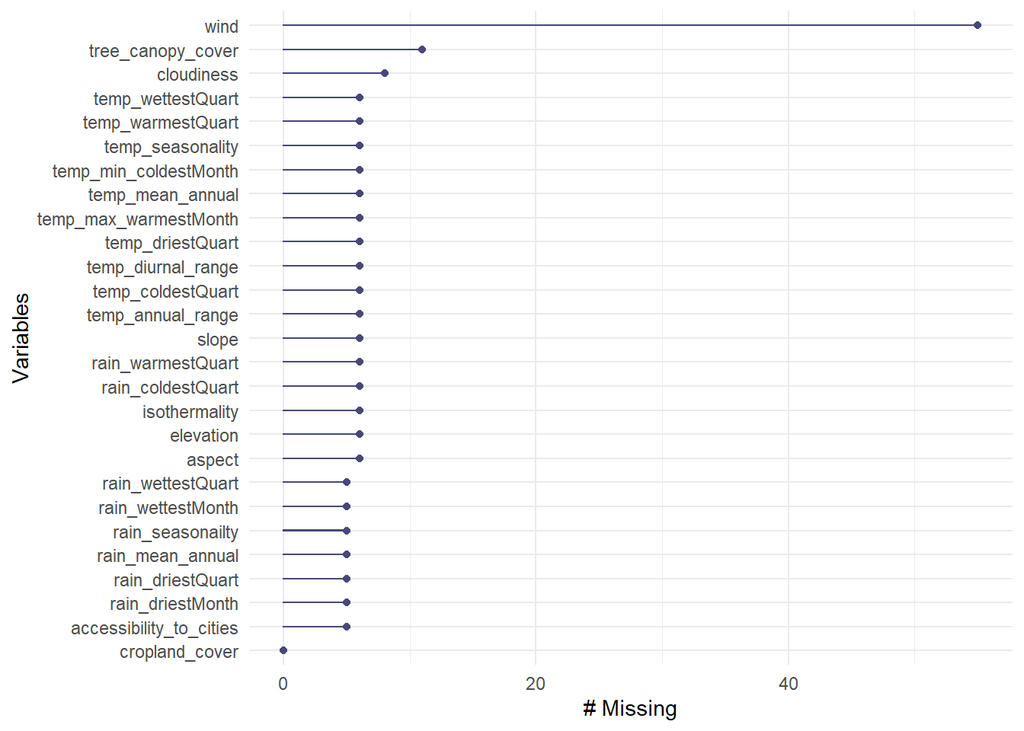

```r
gg_miss_var(env_vars_tidy)
```

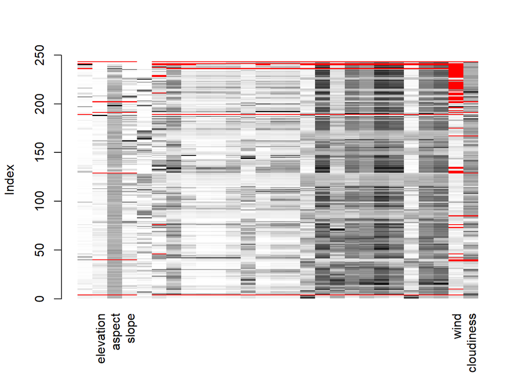

```r
matrixplot(env_vars_tidy)
```

```r
#all of the categories have some level of missingness except cropland cover. Wind has the most missing variables at 55 missing.
```

```r
env_vars_nona <- env_vars_tidy %>%
  drop_na() #This is removing all of the rows in the data frame with NA values.

#This dropped the number of rows from 243 to 188, a difference of 55 rows. This leaves 77% of the original data

summary(env_vars_nona)
```

```
##  accessibility_to_cities   elevation            aspect          slope
##  Min.   :    0.969       Min.   :   2.938   Min.   : 22.0   Min.   :0.0000
##  1st Qu.:   61.758       1st Qu.: 216.089   1st Qu.:162.6   1st Qu.:0.1663
##  Median :  170.568       Median : 400.793   Median :175.0   Median :0.5352
##  Mean   :  500.762       Mean   : 581.938   Mean   :174.4   Mean   :0.7972
##  3rd Qu.:  394.828       3rd Qu.: 729.862   3rd Qu.:186.2   3rd Qu.:1.2368
##  Max.   :10897.463       Max.   :5428.765   Max.   :310.9   Max.   :3.6984
##  cropland_cover   tree_canopy_cover isothermality   rain_coldestQuart
##  Min.   : 0.000   Min.   : 0.00     Min.   :19.35   Min.   :   0.0312
##  1st Qu.: 2.701   1st Qu.: 4.88     1st Qu.:33.23   1st Qu.:  64.9252
##  Median :14.078   Median :17.99     Median :50.42   Median : 161.0212
##  Mean   :20.570   Mean   :21.84     Mean   :51.46   Mean   : 221.7902
##  3rd Qu.:32.647   3rd Qu.:35.84     3rd Qu.:68.13   3rd Qu.: 286.4363
##  Max.   :77.528   Max.   :71.90     Max.   :88.84   Max.   :1271.9904
##  rain_driestMonth  rain_driestQuart rain_mean_annual  rain_seasonailty
##  Min.   :  0.000   Min.   :  0.00   Min.   :  14.16   Min.   : 11.16
##  1st Qu.:  3.122   1st Qu.: 17.93   1st Qu.: 553.39   1st Qu.: 35.58
##  Median : 19.208   Median : 77.33   Median : 990.26   Median : 58.50
##  Mean   : 32.306   Mean   :114.01   Mean   :1142.69   Mean   : 62.11
##  3rd Qu.: 50.598   3rd Qu.:174.84   3rd Qu.:1694.88   3rd Qu.: 87.57
##  Max.   :207.649   Max.   :676.94   Max.   :3938.53   Max.   :152.52
##  rain_warmestQuart rain_wettestMonth rain_wettestQuart  temp_annual_range
##  Min.   :   0.0    Min.   :  3.757   Min.   :   8.929   Min.   : 6.896
##  1st Qu.: 124.6    1st Qu.: 81.513   1st Qu.: 221.649   1st Qu.:15.094
##  Median : 229.1    Median :146.655   Median : 413.012   Median :22.366
##  Mean   : 311.1    Mean   :187.733   Mean   : 494.351   Mean   :23.018
##  3rd Qu.: 431.9    3rd Qu.:296.827   3rd Qu.: 762.066   3rd Qu.:29.497
##  Max.   :1385.1    Max.   :592.526   Max.   :1552.554   Max.   :50.631
##  temp_coldestQuart temp_diurnal_range temp_driestQuart  temp_max_warmestMonth
##  Min.   :-24.744   Min.   : 5.530     Min.   :-19.847   Min.   : 6.586
##  1st Qu.:  2.405   1st Qu.: 8.508     1st Qu.:  9.728   1st Qu.:26.178
##  Median : 15.839   Median :10.457     Median : 21.099   Median :30.497
##  Mean   : 12.338   Mean   :10.508     Mean   : 16.839   Mean   :29.636
##  3rd Qu.: 22.464   3rd Qu.:12.261     3rd Qu.: 24.833   3rd Qu.:33.369
##  Max.   : 26.528   Max.   :16.269     Max.   : 35.217   Max.   :43.842
##  temp_mean_annual temp_min_coldestMonth temp_seasonality  temp_warmestQuart
##  Min.   :-8.345   Min.   :-30.679       Min.   :  2.994   Min.   : 2.629
##  1st Qu.:10.311   1st Qu.: -1.750       1st Qu.: 12.786   1st Qu.:19.309
##  Median :21.539   Median :  9.513       Median : 36.659   Median :24.715
##  Mean   :17.973   Mean   :  6.618       Mean   : 42.592   Mean   :23.193
##  3rd Qu.:24.570   3rd Qu.: 16.502       3rd Qu.: 65.810   3rd Qu.:27.240
##  Max.   :28.250   Max.   : 23.333       Max.   :145.221   Max.   :35.217
##  temp_wettestQuart      wind          cloudiness
##  Min.   :-0.1797   Min.   : 1.203   Min.   : 50.36
##  1st Qu.:13.0862   1st Qu.: 2.196   1st Qu.:158.67
##  Median :22.4295   Median : 2.777   Median :202.51
##  Mean   :19.0575   Mean   : 3.071   Mean   :194.70
##  3rd Qu.:24.9334   3rd Qu.: 3.707   3rd Qu.:236.87
##  Max.   :31.8527   Max.   :11.188   Max.   :322.19
```

```r
skim(env_vars_nona) #this is to get a better sense of the data after the NA's have been dropped
```

Data summary

| Name | env_vars_nona |
| --- | --- |
| Number of rows | 188 |
| Number of columns | 27 |
| _______________________ |  |
| Column type frequency: |  |
| numeric | 27 |
| ________________________ |  |
| Group variables | None |

**Variable type: numeric**

| skim_variable | n_missing | complete_rate | mean | sd | p0 | p25 | p50 | p75 | p100 | hist |
| --- | --- | --- | --- | --- | --- | --- | --- | --- | --- | --- |
| accessibility_to_cities | 0 | 1 | 500.76 | 1220.16 | 0.97 | 61.76 | 170.57 | 394.83 | 10897.46 | ▇▁▁▁▁ |
| elevation | 0 | 1 | 581.94 | 634.35 | 2.94 | 216.09 | 400.79 | 729.86 | 5428.77 | ▇▁▁▁▁ |
| aspect | 0 | 1 | 174.44 | 27.56 | 22.00 | 162.64 | 175.03 | 186.20 | 310.88 | ▁▁▇▂▁ |
| slope | 0 | 1 | 0.80 | 0.78 | 0.00 | 0.17 | 0.54 | 1.24 | 3.70 | ▇▃▂▁▁ |
| cropland_cover | 0 | 1 | 20.57 | 21.26 | 0.00 | 2.70 | 14.08 | 32.65 | 77.53 | ▇▃▂▂▁ |
| tree_canopy_cover | 0 | 1 | 21.84 | 19.08 | 0.00 | 4.88 | 17.99 | 35.84 | 71.90 | ▇▅▃▂▁ |
| isothermality | 0 | 1 | 51.46 | 18.56 | 19.35 | 33.23 | 50.42 | 68.13 | 88.84 | ▇▇▆▆▅ |
| rain_coldestQuart | 0 | 1 | 221.79 | 217.84 | 0.03 | 64.93 | 161.02 | 286.44 | 1271.99 | ▇▂▁▁▁ |
| rain_driestMonth | 0 | 1 | 32.31 | 38.02 | 0.00 | 3.12 | 19.21 | 50.60 | 207.65 | ▇▂▁▁▁ |
| rain_driestQuart | 0 | 1 | 114.01 | 124.88 | 0.00 | 17.93 | 77.33 | 174.84 | 676.94 | ▇▃▁▁▁ |
| rain_mean_annual | 0 | 1 | 1142.69 | 816.61 | 14.16 | 553.39 | 990.26 | 1694.89 | 3938.53 | ▇▅▃▂▁ |
| rain_seasonailty | 0 | 1 | 62.11 | 32.31 | 11.16 | 35.58 | 58.50 | 87.57 | 152.52 | ▇▇▅▃▁ |
| rain_warmestQuart | 0 | 1 | 311.08 | 271.15 | 0.00 | 124.63 | 229.11 | 431.85 | 1385.11 | ▇▃▂▁▁ |
| rain_wettestMonth | 0 | 1 | 187.73 | 131.81 | 3.76 | 81.51 | 146.65 | 296.83 | 592.53 | ▇▅▃▂▁ |
| rain_wettestQuart | 0 | 1 | 494.35 | 347.36 | 8.93 | 221.65 | 413.01 | 762.07 | 1552.55 | ▇▅▃▂▁ |
| temp_annual_range | 0 | 1 | 23.02 | 9.41 | 6.90 | 15.09 | 22.37 | 29.50 | 50.63 | ▇▇▇▂▁ |
| temp_coldestQuart | 0 | 1 | 12.34 | 11.72 | -24.74 | 2.40 | 15.84 | 22.46 | 26.53 | ▁▁▅▃▇ |
| temp_diurnal_range | 0 | 1 | 10.51 | 2.58 | 5.53 | 8.51 | 10.46 | 12.26 | 16.27 | ▅▇▇▆▂ |
| temp_driestQuart | 0 | 1 | 16.84 | 11.05 | -19.85 | 9.73 | 21.10 | 24.83 | 35.22 | ▁▂▂▇▆ |
| temp_max_warmestMonth | 0 | 1 | 29.64 | 6.38 | 6.59 | 26.18 | 30.50 | 33.37 | 43.84 | ▁▂▅▇▂ |
| temp_mean_annual | 0 | 1 | 17.97 | 8.31 | -8.35 | 10.31 | 21.54 | 24.57 | 28.25 | ▁▁▃▂▇ |
| temp_min_coldestMonth | 0 | 1 | 6.62 | 11.54 | -30.68 | -1.75 | 9.51 | 16.50 | 23.33 | ▁▁▆▅▇ |
| temp_seasonality | 0 | 1 | 42.59 | 31.85 | 2.99 | 12.79 | 36.66 | 65.81 | 145.22 | ▇▅▅▁▁ |
| temp_warmestQuart | 0 | 1 | 23.19 | 5.86 | 2.63 | 19.31 | 24.72 | 27.24 | 35.22 | ▁▁▃▇▂ |
| temp_wettestQuart | 0 | 1 | 19.06 | 7.43 | -0.18 | 13.09 | 22.43 | 24.93 | 31.85 | ▂▃▅▇▅ |
| wind | 0 | 1 | 3.07 | 1.32 | 1.20 | 2.20 | 2.78 | 3.71 | 11.19 | ▇▅▁▁▁ |
| cloudiness | 0 | 1 | 194.70 | 58.40 | 50.36 | 158.67 | 202.51 | 236.87 | 322.19 | ▂▃▇▇▂ |

```r
# Creating a subset of the of the environmental variables so that there are not so many similar variable

env_vars_subset <- env_vars_nona %>%
  select(-rain_driestMonth, -rain_wettestMonth, -temp_max_warmestMonth, -temp_min_coldestMonth) # This is removing the columns that record measurements at the month scale. This is done because the quarter is also being measured which feels reduntant to me to have them other be analyzed. This still leaves 23 categories to be included in the PCA analysis
```

```r
#Running the Principle Compenents Analysis

envs_vars_pca <- prcomp(env_vars_subset, scale = TRUE) #This code is running the PCA analysis, and scaling the variables so that they are all relative.

envs_vars_pca
```

```
## Standard deviations (1, .., p=23):
##  [1] 2.914848289 2.313791645 1.365172140 1.304137023 1.046922179 0.979998820
##  [7] 0.901775817 0.870148548 0.687067182 0.584806067 0.540603497 0.453652518
## [13] 0.426163703 0.359876048 0.345722651 0.316651001 0.235000670 0.204562380
## [19] 0.105519252 0.076146128 0.036428349 0.018657431 0.006946251
##
## Rotation (n x k) = (23 x 23):
##                                   PC1         PC2          PC3         PC4
## accessibility_to_cities -0.0006726265 -0.06674132  0.166521059 -0.62194614
## elevation               -0.1160702743 -0.05657239 -0.598556060 -0.16635511
## aspect                  -0.0281427542  0.02384968 -0.138795076  0.14211301
## slope                   -0.0275649996 -0.20122966 -0.450969967 -0.21020510
## cropland_cover          -0.1329982278 -0.11161278  0.229367996  0.44731359
## tree_canopy_cover        0.2410140708 -0.23365176 -0.075056977  0.06074986
## isothermality            0.3000620990  0.08958166 -0.087024685 -0.13001288
## rain_coldestQuart        0.2148367367 -0.15575402  0.027437769  0.07465732
## rain_driestQuart         0.1839622021 -0.28583124  0.100534977 -0.02532031
## rain_mean_annual         0.2954735186 -0.19015310 -0.078309021  0.04708436
## rain_seasonailty         0.0124497082  0.34588701 -0.222619210 -0.06130694
## rain_warmestQuart        0.2268243597 -0.19862852 -0.109747381 -0.01611718
## rain_wettestQuart        0.2894663853 -0.10250986 -0.159838543  0.07875119
## temp_annual_range       -0.3044676973  0.05113699 -0.092202462  0.11591087
## temp_coldestQuart        0.2918420438  0.21283306  0.040307514 -0.02912513
## temp_diurnal_range      -0.0927125832  0.33503405 -0.243976151 -0.01479688
## temp_driestQuart         0.2091253235  0.27057792  0.060901005 -0.03693631
## temp_mean_annual         0.2592608134  0.27485289  0.047958814  0.01801002
## temp_seasonality        -0.3050128151 -0.05849626 -0.004345736  0.12007275
## temp_warmestQuart        0.1586426361  0.34365024  0.073652573  0.11008149
## temp_wettestQuart        0.2424970215  0.20003100  0.005662472  0.05505385
## wind                    -0.1205564078 -0.01926244  0.373447731 -0.48037814
## cloudiness               0.1658575446 -0.30606071  0.028356781  0.07260053
##                                  PC5          PC6          PC7         PC8
## accessibility_to_cities -0.028330181  0.117840828  0.296988392 -0.14849314
## elevation               -0.042408212 -0.147008239 -0.033537269 -0.21931102
## aspect                  -0.638415985  0.673803332  0.060326461  0.08747525
## slope                   -0.034496931 -0.105930714 -0.482987384  0.24944613
## cropland_cover          -0.046881373  0.009109824 -0.378717798 -0.30670275
## tree_canopy_cover        0.122772770  0.091594831  0.193363897  0.14495089
## isothermality           -0.145168565 -0.131904263  0.071963152 -0.23363596
## rain_coldestQuart       -0.408579602 -0.248740767  0.261089674  0.16529240
```

[output cut: 96 more lines]

```
## rain_driestQuart        -0.013198796 -0.0019841155  7.214198e-04
## rain_mean_annual        -0.032395682  0.0319808259 -5.736176e-05
## rain_seasonailty         0.003031538  0.0073208068 -4.874057e-04
## rain_warmestQuart        0.081264491  0.0042677540 -1.414822e-03
## rain_wettestQuart       -0.076126866 -0.0023123134 -2.440240e-03
## temp_annual_range        0.753821870 -0.1447132114  1.845462e-02
## temp_coldestQuart        0.278579288  0.2195924148  7.857666e-01
## temp_diurnal_range      -0.243099721  0.0476894816 -3.654904e-03
## temp_driestQuart        -0.032593613  0.0010110693  3.699413e-03
## temp_mean_annual        -0.041246910 -0.8320500696 -6.458485e-02
## temp_seasonality        -0.515118663 -0.1180134746  5.064596e-01
## temp_warmestQuart       -0.070793082  0.4694172337 -3.485153e-01
## temp_wettestQuart       -0.047622068  0.0114820218  4.318236e-03
## wind                     0.004570054 -0.0057641521  1.994195e-03
## cloudiness              -0.030451970 -0.0083502143  3.478181e-03
```

```r
summary(envs_vars_pca)
```

```
## Importance of components:
##                           PC1    PC2     PC3     PC4     PC5     PC6     PC7
## Standard deviation     2.9148 2.3138 1.36517 1.30414 1.04692 0.98000 0.90178
## Proportion of Variance 0.3694 0.2328 0.08103 0.07395 0.04765 0.04176 0.03536
## Cumulative Proportion  0.3694 0.6022 0.68320 0.75715 0.80480 0.84656 0.88192
##                            PC8     PC9    PC10    PC11    PC12   PC13    PC14
## Standard deviation     0.87015 0.68707 0.58481 0.54060 0.45365 0.4262 0.35988
## Proportion of Variance 0.03292 0.02052 0.01487 0.01271 0.00895 0.0079 0.00563
## Cumulative Proportion  0.91484 0.93536 0.95023 0.96294 0.97188 0.9798 0.98541
##                          PC15    PC16   PC17    PC18    PC19    PC20    PC21
## Standard deviation     0.3457 0.31665 0.2350 0.20456 0.10552 0.07615 0.03643
## Proportion of Variance 0.0052 0.00436 0.0024 0.00182 0.00048 0.00025 0.00006
## Cumulative Proportion  0.9906 0.99497 0.9974 0.99919 0.99967 0.99993 0.99998
##                           PC22     PC23
## Standard deviation     0.01866 0.006946
## Proportion of Variance 0.00002 0.000000
## Cumulative Proportion  1.00000 1.000000
```

```r
#this calling the PCA and issuing a summary so that it can be better understood.
```

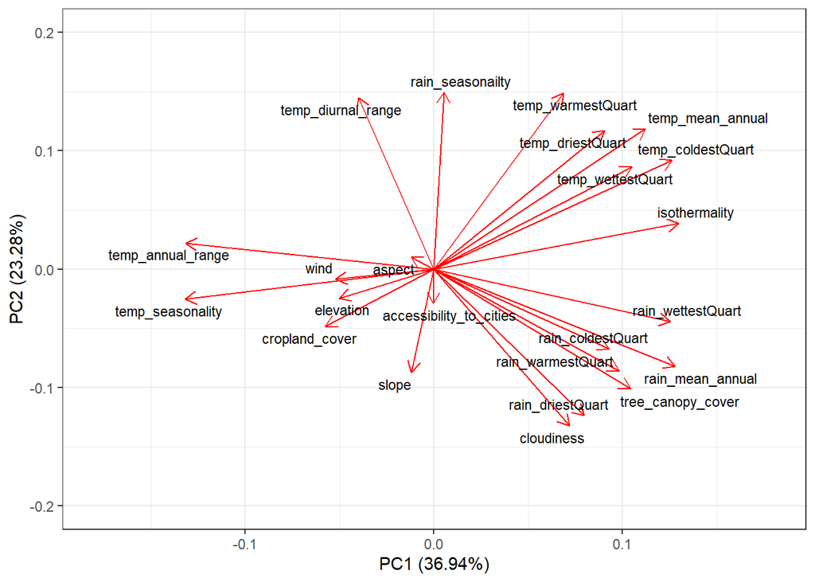

```r
#Creating a biplot from the PCA


env_vars_biplot <- autoplot(envs_vars_pca,
                            colour = NA,
                            loadings.label = TRUE,
                            loadings.label.size = 3,
                            loadings.label.colour = "black",
                            loadings.label.repel = TRUE) +
  theme_bw() +
  scale_y_continuous(limits = c(-0.2, 0.2))#This is creating a biplot to graphically visualize the first two principle components.

env_vars_biplot
```

**Figure 1. Principle Components Biplot of Environmental Variables** This be plot shows the relationship between the environmental variables in a two dimensional way, as a part of a principle components analysis.

3. Key take aways from the PCA
- The first two principle components account for 60.22% of the variance in this analysis. PC1 acounts for 36.94% and PC2 accounts for 23.28%.
- The annual temperature range and the temperature seasonality are the two largest contributers in PC1, while accessiblity to cities is the smallest contributer in PC1.
- The rain seasonality and the warmest temperature quarter are the two largest contributers to PC2, while wind is the smallest contributer to PC2
- There is a strong positive correlation between the warmest temperature quarter, the coldest temperature quarter and the mean annual temperature. This result is expected. Similarly there is positive correlation between the wettest rain quarter, the dryest rain quarter and the mean annual rain.
- There appears to be very little correlation, to maybe a slight negative correlation between cropland cover and tree canopy cover.
- There is a strong negative correlation between cropland cover and annual mean temperature.